# HTML report

*3. The CommitteeEMail.csv file documents 129 email communications for a particular committee assignment over a three-month period and involving a total of 29 people. The file provides you with information on who each email was From, whom the email was directed To, and the Date of the email. The Members.csv file notes the Discipline and Role of each Person participating in the communications. Disciplines are BUSiness or NON-business. Roles include Faculty, Staff, and Administrator. Write the R code to complete the following tasks to analyze the network underlying the email communications.*

*Submit your R code and output file (use filename: ‘LastName_FirstName_Project_Qs3_MIS668A’); written responses for this question can be submitted next to the question in this document. Please submit either .Rmd files or R script files only.* *(15 points)*

*a. Develop the graph data frame.* *b. Display the graph, depicting members from business disciplines in Blue and non-business disciplines in Yellow.*

*QUESTION-a*

## Import packages going to me used in this assignment

## Importing Collaboration Network DATA

## Exploring the dataset

### CommitteeEMail

|  | From | To | Date |
| --- | --- | --- | --- |
| 1 | KVA | RLL | 12/10/2015 9:55 |
| 2 | KVA | RAA | 12/10/2015 9:55 |
| 3 | KVA | LQA | 12/10/2015 9:55 |
| 4 | KVA | CQR | 12/10/2015 9:55 |
| 5 | KVA | VAS | 12/10/2015 9:55 |
| 6 | RLL | RAA | 12/10/2015 9:53 |

```
Rows: 295
Columns: 3
$ From <chr> "KVA", "KVA", "KVA", "KVA", "KVA", "RLL", "RLL", "RLL", "RLL", "RLL", "RAK", "RLL", "KVA", "LQA", "RLL", "RLL", "RLL", "RLL", "RLL", "RLL", "RLL", "RLL", "RLL", "RLL", "KVA", "RLL", "RAA", "RAA", "RAA", "RAA", "RAA", "KVA", "KVA", "KVA…
$ To   <chr> "RLL", "RAA", "LQA", "CQR", "VAS", "RAA", "LQA", "KVA", "CQR", "VAS", "RLL", "RAK", "RLL", "RLL", "RAA", "KVA", "LQA", "VAS", "CQR", "RAA", "KVA", "LQA", "VAS", "CQR", "RLL", "KVA", "RLL", "KVA", "LQA", "VAS", "CQR", "RLL", "LQA", "VAS…
$ Date <chr> "12/10/2015 9:55", "12/10/2015 9:55", "12/10/2015 9:55", "12/10/2015 9:55", "12/10/2015 9:55", "12/10/2015 9:53", "12/10/2015 9:53", "12/10/2015 9:53", "12/10/2015 9:53", "12/10/2015 9:53", "12/10/2015 9:51", "12/10/2015 9:50", "12/9/2…
```

### Members

|  | Person | Role | Discipline |
| --- | --- | --- | --- |
| 1 | KVA | F | BUS |
| 2 | RLL | F | BUS |
| 3 | RAK | A | NON |
| 4 | LQA | F | BUS |
| 5 | RAA | F | BUS |
| 6 | LOR | F | BUS |

## Feature engineering

|  | Person | Role | Discipline |
| --- | --- | --- | --- |
| 1 | KVA | F | BUS |
| 2 | RLL | F | BUS |
| 3 | RAK | A | NON |
| 4 | LQA | F | BUS |
| 5 | RAA | F | BUS |
| 6 | LOR | F | BUS |

|  | From | To | Date |
| --- | --- | --- | --- |
| 1 | KVA | RLL | 12/10/2015 9:55 |
| 2 | KVA | RAA | 12/10/2015 9:55 |
| 3 | KVA | LQA | 12/10/2015 9:55 |
| 4 | KVA | CQR | 12/10/2015 9:55 |
| 5 | KVA | VAS | 12/10/2015 9:55 |
| 6 | RLL | RAA | 12/10/2015 9:53 |

|  | Person | Role | Discipline |
| --- | --- | --- | --- |
| 1 | KVA | F | BUS |
| 2 | RLL | F | BUS |
| 3 | RAK | A | NON |
| 4 | LQA | F | BUS |
| 5 | RAA | F | BUS |
| 6 | LOR | F | BUS |

## Merge the two dataset

|  | To | From | Date | Role | Discipline |
| --- | --- | --- | --- | --- | --- |
| 1 | AIF | RLL | 11/17/2015 16:24 | S | BUS |
| 2 | AIF | EKZ | 10/27/2015 9:59 | S | BUS |
| 3 | BIQ | RLL | 11/18/2015 10:31 | F | BUS |
| 4 | BKK | QCJ | 10/26/2015 10:20 | S | BUS |
| 5 | BKK | BRE | 10/26/2015 10:32 | S | BUS |
| 6 | BKK | QCJ | 10/26/2015 13:48 | S | BUS |

Creating an iGraph Style Edgelist

*QUESTION-b*

## CommitteeEMail Network

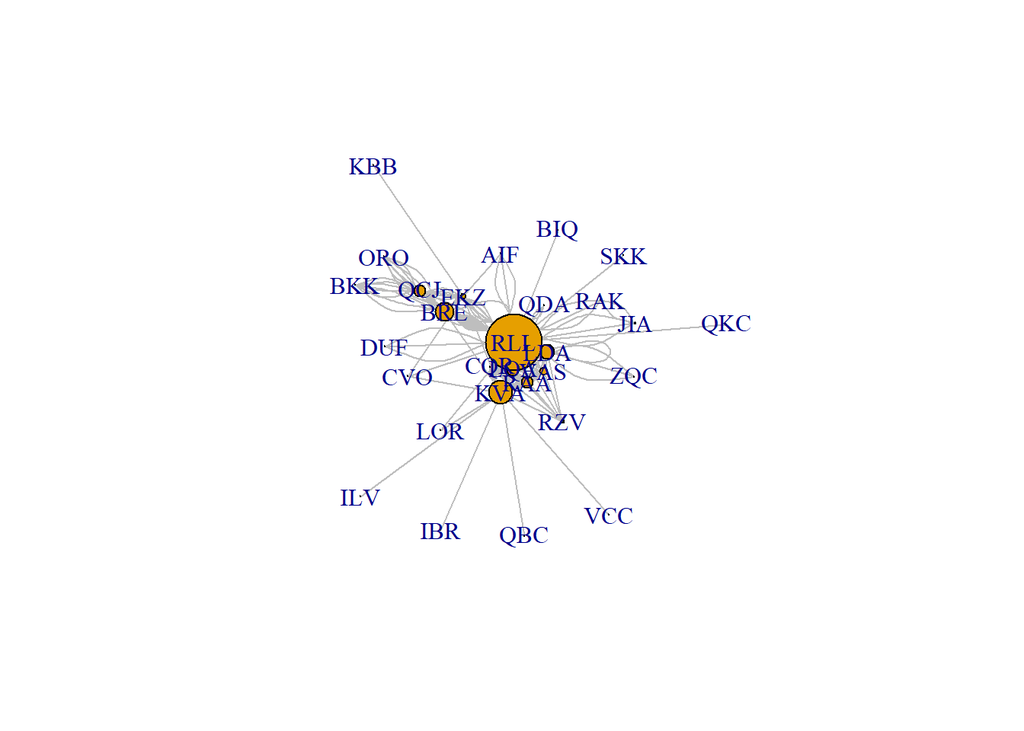

*QUESTION-c*

```
[[1]]
+ 2/29 vertices, named, from 71f3106:
[1] EKZ RLL

[[2]]
+ 1/29 vertex, named, from 71f3106:
[1] RLL

[[3]]
+ 2/29 vertices, named, from 71f3106:
[1] BRE QCJ

[[4]]
+ 6/29 vertices, named, from 71f3106:
[1] BKK EKZ KVA ORO QCJ RLL

[[5]]
+ 7/29 vertices, named, from 71f3106:
[1] KVA LDA LQA RAA RLL RZV VAS

[[6]]
+ 3/29 vertices, named, from 71f3106:
[1] EKZ KVA RLL

[[7]]
+ 1/29 vertex, named, from 71f3106:
[1] RLL

[[8]]
+ 7/29 vertices, named, from 71f3106:
[1] AIF BRE CVO KBB KVA QCJ RLL

[[9]]
+ 1/29 vertex, named, from 71f3106:
[1] KVA

[[10]]
+ 1/29 vertex, named, from 71f3106:
[1] KVA

```

[output cut: 60 more lines]

```
[[26]]
+ 1/29 vertex, named, from 71f3106:
[1] RLL

[[27]]
+ 7/29 vertices, named, from 71f3106:
[1] CQR KVA LDA LQA RAA RLL RZV

[[28]]
+ 1/29 vertex, named, from 71f3106:
[1] KVA

[[29]]
+ 1/29 vertex, named, from 71f3106:
[1] RLL
```